# Homework1

# Problem 1 – Linear Regression Gradient Descent Algorithm

# Problem 2-Linear Regression on Real Dataset

*In this exercise, we experiment applying linear regression modeling to a real-world data, the California Housing Dataset.*

## Importing the libraries

```python
!pip install numpy #installing numpy
!pip install pandas #installing pandas
!pip install matplotlib #installing matplotlib
!pip install seaborn #installing seaborn
!pip install scikit-learn #installing scikit learn
import numpy as np  #importing numpy
import pandas as pd #importing pandas
import seaborn as sns #importing seaborn
import pandas as pd #importing pandas
import matplotlib.pyplot as plt
pd.set_option('display.max_columns',500) #allows for up to 500 columns to be displayed when viewing a dataframe
plt.style.use("seaborn-v0_8-whitegrid") ##a style that can be used for plots
```

## 1. Fetch the data

```python
!pip install --upgrade certifi
import ssl
import certifi

def ssl_context():
    return ssl.create_default_context(cafile=certifi.where())

ssl._create_default_https_context = ssl_context
```

```python
from sklearn.datasets import fetch_california_housing
cal = fetch_california_housing(as_frame=True)
df=cal.frame
df.head()
```

|  | MedInc | HouseAge | AveRooms | AveBedrms | Population | AveOccup | Latitude | Longitude | MedHouseVal |
| --- | --- | --- | --- | --- | --- | --- | --- | --- | --- |
| 0 | 8.3252 | 41.0 | 6.984127 | 1.023810 | 322.0 | 2.555556 | 37.88 | -122.23 | 4.526 |
| 1 | 8.3014 | 21.0 | 6.238137 | 0.971880 | 2401.0 | 2.109842 | 37.86 | -122.22 | 3.585 |
| 2 | 7.2574 | 52.0 | 8.288136 | 1.073446 | 496.0 | 2.802260 | 37.85 | -122.24 | 3.521 |
| 3 | 5.6431 | 52.0 | 5.817352 | 1.073059 | 558.0 | 2.547945 | 37.85 | -122.25 | 3.413 |
| 4 | 3.8462 | 52.0 | 6.281853 | 1.081081 | 565.0 | 2.181467 | 37.85 | -122.25 | 3.422 |

```python
df.info()
```

```
<class 'pandas.core.frame.DataFrame'>
RangeIndex: 20640 entries, 0 to 20639
Data columns (total 9 columns):
 #   Column       Non-Null Count  Dtype
---  ------       --------------  -----
 0   MedInc       20640 non-null  float64
 1   HouseAge     20640 non-null  float64
 2   AveRooms     20640 non-null  float64
 3   AveBedrms    20640 non-null  float64
 4   Population   20640 non-null  float64
 5   AveOccup     20640 non-null  float64
 6   Latitude     20640 non-null  float64
 7   Longitude    20640 non-null  float64
 8   MedHouseVal  20640 non-null  float64
dtypes: float64(9)
memory usage: 1.4 MB
```

## Splitting the dataset into the Training set and Test set

```python
#choosing target
target = "MedHouseVal"
#setting input features
X = df.drop(columns=[target])
#setting target
y = df[target]
print("X shape:", X.shape)
print("y shape:", y.shape)
#spliting the dataset into train and test
from sklearn.model_selection import train_test_split
X_train, X_test, y_train, y_test = train_test_split(X, y, test_size = 1/3, random_state = 42)
#spliting the dataset into train and test
from sklearn.model_selection import train_test_split
X_train, X_test, y_train, y_test = train_test_split(X, y, test_size = 1/3, random_state = 42)
```

```
X shape: (20640, 8)
y shape: (20640,)
```

## Scale numeric features

```python
from sklearn.pipeline import Pipeline
from sklearn.preprocessing import StandardScaler
from sklearn.linear_model import LinearRegression

ols = Pipeline ([("Scaler", StandardScaler()), ("model", LinearRegression())])
```

## 4. Train Linear Regression model

## 5 Compute MSE and RMSE

```python
from sklearn.metrics import mean_squared_error, mean_absolute_error, r2_score
def eval_model(name, model, X_tr, y_tr, X_te, y_te):
    model.fit(X_tr, y_tr)
    pred_tr=model.predict(X_tr)
    pred_te=model.predict(X_te)

    final_est = model.named_steps["model"]
    coef = getattr(final_est, "coef_", None)
    intercept = getattr(final_est, "intercept_", None)

    return {
    "Model": name,
     "Train_RMSE": float(np.sqrt(mean_squared_error(y_tr, pred_tr))),
     "Test_RMSE": float(np.sqrt(mean_squared_error(y_te,pred_te))),
      "Train_MSE": float(mean_absolute_error(y_tr,pred_tr)),
      "Test_MSE": float(mean_absolute_error(y_te, pred_te)),
      "Train_R2": float(r2_score(y_tr,pred_tr)),
       "Test_R2": float(r2_score(y_te,pred_te)),
        "coff": coef,
        "Feature": X_tr.columns,
        "inter":intercept
    }
```

```python
results = eval_model("OLS", ols, X_train, y_train, X_test, y_test)
df_results = pd.DataFrame([results])
df_results_linearreg_score=df_results.drop(['coff', 'Feature', 'inter'], axis=1)
```

```python
df_results_linearreg_score
```

|  | Model | Train_RMSE | Test_RMSE | Train_MSE | Test_MSE | Train_R2 | Test_R2 |
| --- | --- | --- | --- | --- | --- | --- | --- |
| 0 | OLS | 0.720799 | 0.7332 | 0.529148 | 0.529868 | 0.609603 | 0.596705 |

```python
df_results_linearreg_coeff=df_results.drop(['Train_RMSE', 'Test_RMSE', 'Train_MSE', 'Test_MSE', 'Train_R2', 'Test_R2'], axis=1)
# Extract values from dataframe
intercept = df_results_linearreg_coeff["inter"].iloc[0]
coefficients = df_results_linearreg_coeff["coff"].iloc[0]
feature_names = df_results_linearreg_coeff["Feature"].iloc[0]

# Convert to list (if needed)
coefficients = list(coefficients)
feature_names = list(feature_names)

# Print equation
equation = f"target = {intercept:.6f}"

for coef, feature in zip(coefficients, feature_names):
    equation += f" + ({coef:.6f} * {feature})"

print(equation)
```

```
target = 2.066645 + (0.846924 * MedInc) + (0.118799 * HouseAge) + (-0.299525 * AveRooms) + (0.348115 * AveBedrms) + (0.000040 * Population) + (-0.041724 * AveOccup) + (-0.894496 * Latitude) + (-0.870096 * Longitude)
```

### 6. Sort features by absolute value using correlation and mutual information

#### Sort features by absolute value using correlation

##### Correlation with target (Used for feature importance and helps prediction)

```python
# Compute correlations with target
corr_series = X_train.corrwith(y_train)

# Take absolute value
corr_abs = corr_series.abs()

# Create DataFrame
df_corr = pd.DataFrame({
    "Feature": corr_series.index,
    "Correlation": corr_series.values,
    "Abs_Correlation": corr_abs.values
})

# Sort by absolute correlation
df_corr = df_corr.sort_values("Abs_Correlation", ascending=False).reset_index(drop=True)

df_corr.head(20)
```

|  | Feature | Correlation | Abs_Correlation |
| --- | --- | --- | --- |
| 0 | MedInc | 0.689075 | 0.689075 |
| 1 | AveRooms | 0.151918 | 0.151918 |
| 2 | Latitude | -0.140136 | 0.140136 |
| 3 | HouseAge | 0.104243 | 0.104243 |
| 4 | Longitude | -0.050082 | 0.050082 |
| 5 | AveBedrms | -0.048867 | 0.048867 |
| 6 | Population | -0.023560 | 0.023560 |
| 7 | AveOccup | -0.020558 | 0.020558 |

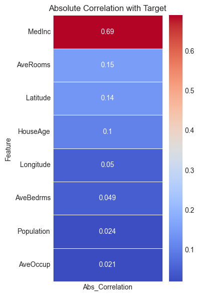

```python
import seaborn as sns
import matplotlib.pyplot as plt

# Set feature as index
df_corr_heat = df_corr.set_index("Feature")[["Abs_Correlation"]]

plt.figure(figsize=(4, 6))
sns.heatmap(df_corr_heat,
            annot=True,
            cmap="coolwarm",
            linewidths=0.5)

plt.title("Absolute Correlation with Target")
plt.tight_layout()
plt.show()
```

##### Correlation between features (Used for multicollinearity, Helps model stability)

```python
corrMatrix=X.corr().abs()
df_corrMatrix=pd.DataFrame(corrMatrix)
df_corrMatrix
```

|  | MedInc | HouseAge | AveRooms | AveBedrms | Population | AveOccup | Latitude | Longitude |
| --- | --- | --- | --- | --- | --- | --- | --- | --- |
| MedInc | 1.000000 | 0.119034 | 0.326895 | 0.062040 | 0.004834 | 0.018766 | 0.079809 | 0.015176 |
| HouseAge | 0.119034 | 1.000000 | 0.153277 | 0.077747 | 0.296244 | 0.013191 | 0.011173 | 0.108197 |
| AveRooms | 0.326895 | 0.153277 | 1.000000 | 0.847621 | 0.072213 | 0.004852 | 0.106389 | 0.027540 |
| AveBedrms | 0.062040 | 0.077747 | 0.847621 | 1.000000 | 0.066197 | 0.006181 | 0.069721 | 0.013344 |
| Population | 0.004834 | 0.296244 | 0.072213 | 0.066197 | 1.000000 | 0.069863 | 0.108785 | 0.099773 |
| AveOccup | 0.018766 | 0.013191 | 0.004852 | 0.006181 | 0.069863 | 1.000000 | 0.002366 | 0.002476 |
| Latitude | 0.079809 | 0.011173 | 0.106389 | 0.069721 | 0.108785 | 0.002366 | 1.000000 | 0.924664 |
| Longitude | 0.015176 | 0.108197 | 0.027540 | 0.013344 | 0.099773 | 0.002476 | 0.924664 | 1.000000 |

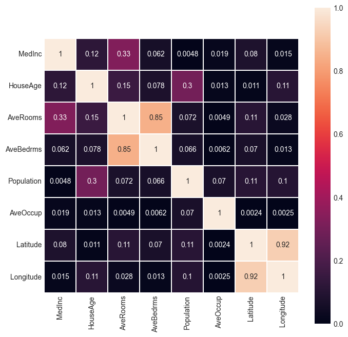

```python
colormap = plt.cm.RdBu
plt.figure(figsize=(8,8))
sns.heatmap(df_corrMatrix, linewidth=0.1, vmax=1.0, vmin=0, square=True, annot=True)
```

**Sort Features by Mutual Information**

```python
from sklearn.feature_selection import mutual_info_regression
import pandas as pd

mi_scores = mutual_info_regression(X_train, y_train, random_state=21)

df_mi = pd.DataFrame({
    "Feature": X_train.columns,
    "Mutual_Information": mi_scores
})

df_mi = df_mi.sort_values(
    "Mutual_Information",
    ascending=False
).reset_index(drop=True)

df_mi.head(20)
```

|  | Feature | Mutual_Information |
| --- | --- | --- |
| 0 | MedInc | 0.380122 |
| 1 | Longitude | 0.379757 |
| 2 | Latitude | 0.354531 |
| 3 | AveRooms | 0.091331 |
| 4 | AveOccup | 0.073808 |
| 5 | HouseAge | 0.031459 |
| 6 | AveBedrms | 0.027574 |
| 7 | Population | 0.022005 |

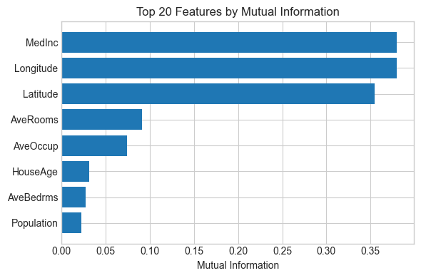

```python
# Select top 20
top_n = 20
df_mi_top = df_mi.head(top_n).sort_values("Mutual_Information")

plt.figure(figsize=(6, 4))
plt.barh(df_mi_top["Feature"], df_mi_top["Mutual_Information"])
plt.xlabel("Mutual Information")
plt.title(f"Top {top_n} Features by Mutual Information")
plt.tight_layout()
plt.show()
```

```python
df_feature_rank = pd.merge(
    df_corr[["Feature", "Abs_Correlation"]],
    df_mi,
    on="Feature",
    how="inner"
)

df_feature_rank = df_feature_rank.sort_values(
    "Abs_Correlation",
    ascending=False
).reset_index(drop=True)

df_feature_rank.head(20)
```

|  | Feature | Abs_Correlation | Mutual_Information |
| --- | --- | --- | --- |
| 0 | MedInc | 0.689075 | 0.380122 |
| 1 | AveRooms | 0.151918 | 0.091331 |
| 2 | Latitude | 0.140136 | 0.354531 |
| 3 | HouseAge | 0.104243 | 0.031459 |
| 4 | Longitude | 0.050082 | 0.379757 |
| 5 | AveBedrms | 0.048867 | 0.027574 |
| 6 | Population | 0.023560 | 0.022005 |
| 7 | AveOccup | 0.020558 | 0.073808 |

## 7. Sort features by absolute using coefficient magnitude

```python
df_coef = pd.DataFrame({
    "Feature": X_train.columns,
    "Coefficient": coefficients,
    "Abs_Coefficient": np.abs(coefficients)
})

df_coef = df_coef.sort_values(
    "Abs_Coefficient",
    ascending=False
).reset_index(drop=True)

df_coef.head(20)
```

|  | Feature | Coefficient | Abs_Coefficient |
| --- | --- | --- | --- |
| 0 | Latitude | -0.894496 | 0.894496 |
| 1 | Longitude | -0.870096 | 0.870096 |
| 2 | MedInc | 0.846924 | 0.846924 |
| 3 | AveBedrms | 0.348115 | 0.348115 |
| 4 | AveRooms | -0.299525 | 0.299525 |
| 5 | HouseAge | 0.118799 | 0.118799 |
| 6 | AveOccup | -0.041724 | 0.041724 |
| 7 | Population | 0.000040 | 0.000040 |

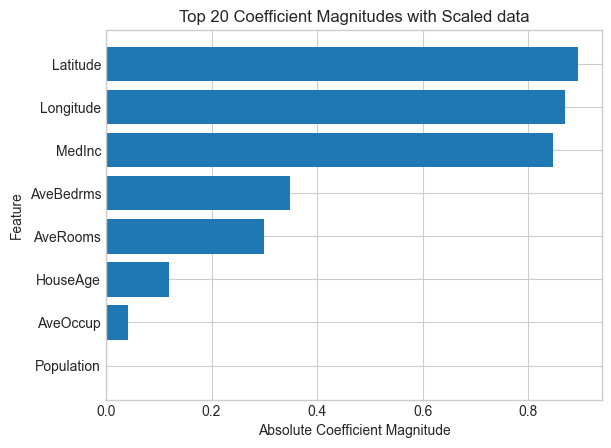

```python
import matplotlib.pyplot as plt

# Select top 20 features by absolute coefficient
top20 = df_coef.head(20)

plt.figure()
plt.barh(top20["Feature"], top20["Abs_Coefficient"])
plt.gca().invert_yaxis()  # Largest at top

plt.xlabel("Absolute Coefficient Magnitude")
plt.ylabel("Feature")
plt.title("Top 20 Coefficient Magnitudes with Scaled data")
plt.show()
```

#### Let us investigate the coeffieicnt with raw data

```python
# Model
regressor = LinearRegression()

# Fit on raw data
regressor.fit(X_train, y_train)

# Predictions
pred_tr = regressor.predict(X_train)
pred_te = regressor.predict(X_test)
```

```python
# MSE
train_mse = mean_squared_error(y_train, pred_tr)
test_mse  = mean_squared_error(y_test, pred_te)

# RMSE
train_rmse = np.sqrt(train_mse)
test_rmse  = np.sqrt(test_mse)

# R2
train_r2 = r2_score(y_train, pred_tr)
test_r2  = r2_score(y_test, pred_te)

print("Train MSE:", round(train_mse, 6))
print("Train RMSE:", round(train_rmse, 6))
print("Train R2:", round(train_r2, 6))
print()
print("Test MSE:", round(test_mse, 6))
print("Test RMSE:", round(test_rmse, 6))
print("Test R2:", round(test_r2, 6))
```

```
Train MSE: 0.519552
Train RMSE: 0.720799
Train R2: 0.609603

Test MSE: 0.537582
Test RMSE: 0.7332
Test R2: 0.596705
```

```python
coefficients = regressor.coef_
intercept = regressor.intercept_

feature_names = X_train.columns

print("\nLinear Regression Model:\n")

equation = f"target = {intercept:.6f}"

for coef, feature in zip(coefficients, feature_names):
    equation += f" + ({coef:.6f} * {feature})"

print(equation)
```

```
Linear Regression Model:

target = -37.054743 + (0.445222 * MedInc) + (0.009431 * HouseAge) + (-0.122068 * AveRooms) + (0.779316 * AveBedrms) + (0.000000 * Population) + (-0.003291 * AveOccup) + (-0.419130 * Latitude) + (-0.433892 * Longitude)
```

```python
import pandas as pd
import numpy as np

coefficients = regressor.coef_
feature_names = X_train.columns

df_coef = pd.DataFrame({
    "Feature": feature_names,
    "Coefficient": coefficients,
    "Abs_Coefficient": np.abs(coefficients)
})

df_coef = df_coef.sort_values("Abs_Coefficient", ascending=False)
```

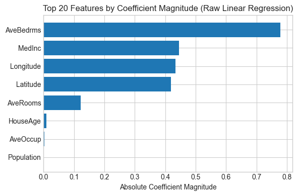

```python
import matplotlib.pyplot as plt

top_n = 20
df_top = df_coef.head(top_n).sort_values("Abs_Coefficient")

plt.figure(figsize=(6,4))
plt.barh(df_top["Feature"], df_top["Abs_Coefficient"])
plt.xlabel("Absolute Coefficient Magnitude")
plt.title("Top 20 Features by Coefficient Magnitude (Raw Linear Regression)")
plt.tight_layout()
plt.show()
```

# Problem 3 – Ridge and Lasso Regularization

## Ridge Regularization

##### In the case of Ridge and Lasso, we will observe closely ciefficient shrinkage and coefficient kills.

##### So, here we have updated our eval_model function

```python
import numpy as np
from sklearn.metrics import mean_squared_error, mean_absolute_error, r2_score

def eval_model(name, model, X_tr, y_tr, X_te, y_te, zero_tol=1e-10):
    model.fit(X_tr, y_tr)

    pred_tr = model.predict(X_tr)
    pred_te = model.predict(X_te)


    final_est = model.named_steps["model"]

    coef = np.ravel(final_est.coef_)
    intercept = float(np.ravel(final_est.intercept_)[0])

    return {
        "Model": name,
        "Train_RMSE": float(np.sqrt(mean_squared_error(y_tr, pred_tr))),
        "Test_RMSE": float(np.sqrt(mean_squared_error(y_te, pred_te))),
        "Train_MSE": float(mean_absolute_error(y_tr, pred_tr)),
        "Test_MSE": float(mean_absolute_error(y_te, pred_te)),
        "Train_R2": float(r2_score(y_tr, pred_tr)),
        "Test_R2": float(r2_score(y_te, pred_te)),

        # coefficient diagnostics
        "Intercept": intercept,
        "Num_Features": int(coef.size),
        "NonZero_Coeff": int(np.sum(np.abs(coef) > zero_tol)),
        "Killed_Coeff": int(np.sum(np.abs(coef) <= zero_tol)),
        "L2_Norm": float(np.linalg.norm(coef, 2)),
        "L1_Norm": float(np.linalg.norm(coef, 1)),
        "Mean_Abs_Coeff": float(np.mean(np.abs(coef))),
        "Max_Abs_Coeff": float(np.max(np.abs(coef))),
    }
```

```python
from sklearn.linear_model import Ridge

results = []

for a in [0.001, 0.01, 0.1, 1, 10]:
    ridge = Pipeline([
        ("scaler", StandardScaler()),
        ("model", Ridge(alpha=a))
    ])

    res = eval_model(f"Ridge_alpha_{a}", ridge, X_train, y_train, X_test, y_test)
    res["Alpha"] = a
    results.append(res)

df_ridge_alpha_results = pd.DataFrame(results).sort_values("Alpha")
df_ridge_alpha_results
```

|  | Model | Train_RMSE | Test_RMSE | Train_MSE | Test_MSE | Train_R2 | Test_R2 | Intercept | Num_Features | NonZero_Coeff | Killed_Coeff | L2_Norm | L1_Norm | Mean_Abs_Coeff | Max_Abs_Coeff | Alpha |
| --- | --- | --- | --- | --- | --- | --- | --- | --- | --- | --- | --- | --- | --- | --- | --- | --- |
| 0 | Ridge_alpha_0.001 | 0.720799 | 0.733200 | 0.529148 | 0.529868 | 0.609603 | 0.596705 | 2.066645 | 8 | 8 | 0 | 1.581524 | 3.419715 | 0.427464 | 0.894495 | 0.001 |
| 1 | Ridge_alpha_0.01 | 0.720799 | 0.733199 | 0.529148 | 0.529868 | 0.609603 | 0.596705 | 2.066645 | 8 | 8 | 0 | 1.581513 | 3.419694 | 0.427462 | 0.894486 | 0.010 |
| 2 | Ridge_alpha_0.1 | 0.720799 | 0.733198 | 0.529148 | 0.529868 | 0.609603 | 0.596706 | 2.066645 | 8 | 8 | 0 | 1.581408 | 3.419483 | 0.427435 | 0.894405 | 0.100 |
| 3 | Ridge_alpha_1 | 0.720799 | 0.733184 | 0.529143 | 0.529864 | 0.609603 | 0.596722 | 2.066645 | 8 | 8 | 0 | 1.580358 | 3.417375 | 0.427172 | 0.893590 | 1.000 |
| 4 | Ridge_alpha_10 | 0.720808 | 0.733053 | 0.529100 | 0.529839 | 0.609593 | 0.596866 | 2.066645 | 8 | 8 | 0 | 1.569969 | 3.396472 | 0.424559 | 0.885535 | 10.000 |

```python
df_ridge_alpha_results.columns
```

```
Index(['Model', 'Train_RMSE', 'Test_RMSE', 'Train_MSE', 'Test_MSE', 'Train_R2',
       'Test_R2', 'Intercept', 'Num_Features', 'NonZero_Coeff', 'Killed_Coeff',
       'L2_Norm', 'L1_Norm', 'Mean_Abs_Coeff', 'Max_Abs_Coeff', 'Alpha'],
      dtype='object')
```

```python
df_ridge_alpha_results_RMSE_R2 = df_ridge_alpha_results.drop(['Intercept', 'Num_Features', 'NonZero_Coeff', 'Killed_Coeff','L2_Norm', 'L1_Norm', 'Mean_Abs_Coeff', 'Max_Abs_Coeff'], axis=1)
```

```python
df_ridge_alpha_results_RMSE_R2
```

|  | Model | Train_RMSE | Test_RMSE | Train_MSE | Test_MSE | Train_R2 | Test_R2 | Alpha |
| --- | --- | --- | --- | --- | --- | --- | --- | --- |
| 0 | Ridge_alpha_0.001 | 0.720799 | 0.733200 | 0.529148 | 0.529868 | 0.609603 | 0.596705 | 0.001 |
| 1 | Ridge_alpha_0.01 | 0.720799 | 0.733199 | 0.529148 | 0.529868 | 0.609603 | 0.596705 | 0.010 |
| 2 | Ridge_alpha_0.1 | 0.720799 | 0.733198 | 0.529148 | 0.529868 | 0.609603 | 0.596706 | 0.100 |
| 3 | Ridge_alpha_1 | 0.720799 | 0.733184 | 0.529143 | 0.529864 | 0.609603 | 0.596722 | 1.000 |
| 4 | Ridge_alpha_10 | 0.720808 | 0.733053 | 0.529100 | 0.529839 | 0.609593 | 0.596866 | 10.000 |

```python
df_ridge_alpha_results_shrinking = df_ridge_alpha_results.drop(['Train_RMSE', 'Test_RMSE', 'Train_MSE', 'Test_MSE', 'Train_R2', 'Test_R2'], axis=1)
```

```python
df_ridge_alpha_results_shrinking
```

|  | Model | Intercept | Num_Features | NonZero_Coeff | Killed_Coeff | L2_Norm | L1_Norm | Mean_Abs_Coeff | Max_Abs_Coeff | Alpha |
| --- | --- | --- | --- | --- | --- | --- | --- | --- | --- | --- |
| 0 | Ridge_alpha_0.001 | 2.066645 | 8 | 8 | 0 | 1.581524 | 3.419715 | 0.427464 | 0.894495 | 0.001 |
| 1 | Ridge_alpha_0.01 | 2.066645 | 8 | 8 | 0 | 1.581513 | 3.419694 | 0.427462 | 0.894486 | 0.010 |
| 2 | Ridge_alpha_0.1 | 2.066645 | 8 | 8 | 0 | 1.581408 | 3.419483 | 0.427435 | 0.894405 | 0.100 |
| 3 | Ridge_alpha_1 | 2.066645 | 8 | 8 | 0 | 1.580358 | 3.417375 | 0.427172 | 0.893590 | 1.000 |
| 4 | Ridge_alpha_10 | 2.066645 | 8 | 8 | 0 | 1.569969 | 3.396472 | 0.424559 | 0.885535 | 10.000 |

```python
results = []

# Log scale from 10^-3 to 10^3
alphas = np.logspace(-3, 3, 20)   # 20 values between 0.001 and 1000

for a in alphas:

    ridge = Pipeline([
        ("scaler", StandardScaler()),
        ("model", Ridge(alpha=a, max_iter=5000))
    ])

    res = eval_model(f"Ridge_alpha_{a:.5f}", ridge,
                     X_train, y_train,
                     X_test, y_test)

    res["Alpha"] = a
    results.append(res)

df_ridge_alpha_results_log = (
    pd.DataFrame(results)
    .sort_values("Alpha")
    .reset_index(drop=True)
)

df_ridge_alpha_results_log
```

|  | Model | Train_RMSE | Test_RMSE | Train_MSE | Test_MSE | Train_R2 | Test_R2 | Intercept | Num_Features | NonZero_Coeff | Killed_Coeff | L2_Norm | L1_Norm | Mean_Abs_Coeff | Max_Abs_Coeff | Alpha |
| --- | --- | --- | --- | --- | --- | --- | --- | --- | --- | --- | --- | --- | --- | --- | --- | --- |
| 0 | Ridge_alpha_0.00100 | 0.720799 | 0.733200 | 0.529148 | 0.529868 | 0.609603 | 0.596705 | 2.066645 | 8 | 8 | 0 | 1.581524 | 3.419715 | 0.427464 | 0.894495 | 0.001000 |
| 1 | Ridge_alpha_0.00207 | 0.720799 | 0.733200 | 0.529148 | 0.529868 | 0.609603 | 0.596705 | 2.066645 | 8 | 8 | 0 | 1.581523 | 3.419713 | 0.427464 | 0.894494 | 0.002069 |
| 2 | Ridge_alpha_0.00428 | 0.720799 | 0.733199 | 0.529148 | 0.529868 | 0.609603 | 0.596705 | 2.066645 | 8 | 8 | 0 | 1.581520 | 3.419708 | 0.427463 | 0.894492 | 0.004281 |
| 3 | Ridge_alpha_0.00886 | 0.720799 | 0.733199 | 0.529148 | 0.529868 | 0.609603 | 0.596705 | 2.066645 | 8 | 8 | 0 | 1.581515 | 3.419697 | 0.427462 | 0.894487 | 0.008859 |
| 4 | Ridge_alpha_0.01833 | 0.720799 | 0.733199 | 0.529148 | 0.529868 | 0.609603 | 0.596705 | 2.066645 | 8 | 8 | 0 | 1.581504 | 3.419675 | 0.427459 | 0.894479 | 0.018330 |
| 5 | Ridge_alpha_0.03793 | 0.720799 | 0.733199 | 0.529148 | 0.529868 | 0.609603 | 0.596705 | 2.066645 | 8 | 8 | 0 | 1.581481 | 3.419629 | 0.427454 | 0.894461 | 0.037927 |
| 6 | Ridge_alpha_0.07848 | 0.720799 | 0.733198 | 0.529148 | 0.529868 | 0.609603 | 0.596706 | 2.066645 | 8 | 8 | 0 | 1.581433 | 3.419534 | 0.427442 | 0.894424 | 0.078476 |
| 7 | Ridge_alpha_0.16238 | 0.720799 | 0.733197 | 0.529148 | 0.529867 | 0.609603 | 0.596707 | 2.066645 | 8 | 8 | 0 | 1.581335 | 3.419337 | 0.427417 | 0.894348 | 0.162378 |
| 8 | Ridge_alpha_0.33598 | 0.720799 | 0.733194 | 0.529147 | 0.529866 | 0.609603 | 0.596710 | 2.066645 | 8 | 8 | 0 | 1.581133 | 3.418930 | 0.427366 | 0.894191 | 0.335982 |
| 9 | Ridge_alpha_0.69519 | 0.720799 | 0.733189 | 0.529145 | 0.529865 | 0.609603 | 0.596717 | 2.066645 | 8 | 8 | 0 | 1.580713 | 3.418089 | 0.427261 | 0.893866 | 0.695193 |
| 10 | Ridge_alpha_1.43845 | 0.720800 | 0.733177 | 0.529141 | 0.529862 | 0.609603 | 0.596729 | 2.066645 | 8 | 8 | 0 | 1.579847 | 3.416349 | 0.427044 | 0.893194 | 1.438450 |
| 11 | Ridge_alpha_2.97635 | 0.720800 | 0.733154 | 0.529132 | 0.529857 | 0.609602 | 0.596755 | 2.066645 | 8 | 8 | 0 | 1.578058 | 3.412757 | 0.426595 | 0.891806 | 2.976351 |
| 12 | Ridge_alpha_6.15848 | 0.720803 | 0.733107 | 0.529117 | 0.529848 | 0.609599 | 0.596807 | 2.066645 | 8 | 8 | 0 | 1.574378 | 3.405355 | 0.425669 | 0.888952 | 6.158482 |
| 13 | Ridge_alpha_12.74275 | 0.720814 | 0.733016 | 0.529090 | 0.529835 | 0.609587 | 0.596906 | 2.066645 | 8 | 8 | 0 | 1.566845 | 3.390165 | 0.423771 | 0.883114 | 12.742750 |
| 14 | Ridge_alpha_26.36651 | 0.720861 | 0.732856 | 0.529059 | 0.529824 | 0.609536 | 0.597083 | 2.066645 | 8 | 8 | 0 | 1.551604 | 3.359268 | 0.419908 | 0.871315 | 26.366509 |
| 15 | Ridge_alpha_54.55595 | 0.721049 | 0.732631 | 0.529104 | 0.529872 | 0.609332 | 0.597330 | 2.066645 | 8 | 8 | 0 | 1.521470 | 3.297526 | 0.412191 | 0.848030 | 54.555948 |
| 16 | Ridge_alpha_112.88379 | 0.721760 | 0.732551 | 0.529522 | 0.530287 | 0.608562 | 0.597418 | 2.066645 | 8 | 8 | 0 | 1.464499 | 3.178396 | 0.397300 | 0.838052 | 112.883789 |
| 17 | Ridge_alpha_233.57215 | 0.724161 | 0.733567 | 0.531362 | 0.532299 | 0.605952 | 0.596301 | 2.066645 | 8 | 8 | 0 | 1.365317 | 2.963238 | 0.370405 | 0.827529 | 233.572147 |
| 18 | Ridge_alpha_483.29302 | 0.730898 | 0.738256 | 0.537041 | 0.538395 | 0.598587 | 0.591123 | 2.066645 | 8 | 8 | 0 | 1.215004 | 2.616709 | 0.327089 | 0.805473 | 483.293024 |
| 19 | Ridge_alpha_1000.00000 | 0.745467 | 0.750568 | 0.550902 | 0.551919 | 0.582424 | 0.577372 | 2.066645 | 8 | 8 | 0 | 1.028617 | 2.146819 | 0.268352 | 0.764320 | 1000.000000 |

```python
df_ridge_alpha_results_RMSE_R2_log = df_ridge_alpha_results_log.drop(['Intercept', 'Num_Features', 'NonZero_Coeff', 'Killed_Coeff','L2_Norm', 'L1_Norm', 'Mean_Abs_Coeff', 'Max_Abs_Coeff'], axis=1)
```

```python
df_ridge_alpha_results_RMSE_R2_log
```

|  | Model | Train_RMSE | Test_RMSE | Train_MSE | Test_MSE | Train_R2 | Test_R2 | Alpha |
| --- | --- | --- | --- | --- | --- | --- | --- | --- |
| 0 | Ridge_alpha_0.00100 | 0.720799 | 0.733200 | 0.529148 | 0.529868 | 0.609603 | 0.596705 | 0.001000 |
| 1 | Ridge_alpha_0.00207 | 0.720799 | 0.733200 | 0.529148 | 0.529868 | 0.609603 | 0.596705 | 0.002069 |
| 2 | Ridge_alpha_0.00428 | 0.720799 | 0.733199 | 0.529148 | 0.529868 | 0.609603 | 0.596705 | 0.004281 |
| 3 | Ridge_alpha_0.00886 | 0.720799 | 0.733199 | 0.529148 | 0.529868 | 0.609603 | 0.596705 | 0.008859 |
| 4 | Ridge_alpha_0.01833 | 0.720799 | 0.733199 | 0.529148 | 0.529868 | 0.609603 | 0.596705 | 0.018330 |
| 5 | Ridge_alpha_0.03793 | 0.720799 | 0.733199 | 0.529148 | 0.529868 | 0.609603 | 0.596705 | 0.037927 |
| 6 | Ridge_alpha_0.07848 | 0.720799 | 0.733198 | 0.529148 | 0.529868 | 0.609603 | 0.596706 | 0.078476 |
| 7 | Ridge_alpha_0.16238 | 0.720799 | 0.733197 | 0.529148 | 0.529867 | 0.609603 | 0.596707 | 0.162378 |
| 8 | Ridge_alpha_0.33598 | 0.720799 | 0.733194 | 0.529147 | 0.529866 | 0.609603 | 0.596710 | 0.335982 |
| 9 | Ridge_alpha_0.69519 | 0.720799 | 0.733189 | 0.529145 | 0.529865 | 0.609603 | 0.596717 | 0.695193 |
| 10 | Ridge_alpha_1.43845 | 0.720800 | 0.733177 | 0.529141 | 0.529862 | 0.609603 | 0.596729 | 1.438450 |
| 11 | Ridge_alpha_2.97635 | 0.720800 | 0.733154 | 0.529132 | 0.529857 | 0.609602 | 0.596755 | 2.976351 |
| 12 | Ridge_alpha_6.15848 | 0.720803 | 0.733107 | 0.529117 | 0.529848 | 0.609599 | 0.596807 | 6.158482 |
| 13 | Ridge_alpha_12.74275 | 0.720814 | 0.733016 | 0.529090 | 0.529835 | 0.609587 | 0.596906 | 12.742750 |
| 14 | Ridge_alpha_26.36651 | 0.720861 | 0.732856 | 0.529059 | 0.529824 | 0.609536 | 0.597083 | 26.366509 |
| 15 | Ridge_alpha_54.55595 | 0.721049 | 0.732631 | 0.529104 | 0.529872 | 0.609332 | 0.597330 | 54.555948 |
| 16 | Ridge_alpha_112.88379 | 0.721760 | 0.732551 | 0.529522 | 0.530287 | 0.608562 | 0.597418 | 112.883789 |
| 17 | Ridge_alpha_233.57215 | 0.724161 | 0.733567 | 0.531362 | 0.532299 | 0.605952 | 0.596301 | 233.572147 |
| 18 | Ridge_alpha_483.29302 | 0.730898 | 0.738256 | 0.537041 | 0.538395 | 0.598587 | 0.591123 | 483.293024 |
| 19 | Ridge_alpha_1000.00000 | 0.745467 | 0.750568 | 0.550902 | 0.551919 | 0.582424 | 0.577372 | 1000.000000 |

## Lasso Regularization

```python
from sklearn.linear_model import Lasso
from sklearn.pipeline import Pipeline
from sklearn.preprocessing import StandardScaler
import pandas as pd

results = []

for a in [0.001, 0.01, 0.1, 1, 10]:

    lasso = Pipeline([
        ("scaler", StandardScaler()),
        ("model", Lasso(alpha=a, max_iter=5000))
    ])

    res = eval_model(f"Lasso_alpha_{a}", lasso,
                     X_train, y_train,
                     X_test, y_test)

    res["Alpha"] = a
    results.append(res)

df_lasso_alpha_results = pd.DataFrame(results).sort_values("Alpha")
df_lasso_alpha_results
```

|  | Model | Train_RMSE | Test_RMSE | Train_MSE | Test_MSE | Train_R2 | Test_R2 | Intercept | Num_Features | NonZero_Coeff | Killed_Coeff | L2_Norm | L1_Norm | Mean_Abs_Coeff | Max_Abs_Coeff | Alpha |
| --- | --- | --- | --- | --- | --- | --- | --- | --- | --- | --- | --- | --- | --- | --- | --- | --- |
| 0 | Lasso_alpha_0.001 | 0.720838 | 0.732693 | 0.529205 | 0.529927 | 0.609561 | 0.597261 | 2.066645 | 8 | 7 | 1 | 1.560854 | 3.364320 | 0.420540 | 0.883839 | 0.001 |
| 1 | Lasso_alpha_0.01 | 0.724630 | 0.732121 | 0.532489 | 0.533153 | 0.605442 | 0.597890 | 2.066645 | 8 | 7 | 1 | 1.382722 | 2.866020 | 0.358252 | 0.793322 | 0.010 |
| 2 | Lasso_alpha_0.1 | 0.820885 | 0.823665 | 0.619617 | 0.621466 | 0.493659 | 0.491045 | 2.066645 | 8 | 3 | 5 | 0.713663 | 0.817908 | 0.102238 | 0.706193 | 0.100 |
| 3 | Lasso_alpha_1 | 1.153615 | 1.154558 | 0.910782 | 0.912475 | 0.000000 | -0.000025 | 2.066645 | 8 | 0 | 8 | 0.000000 | 0.000000 | 0.000000 | 0.000000 | 1.000 |
| 4 | Lasso_alpha_10 | 1.153615 | 1.154558 | 0.910782 | 0.912475 | 0.000000 | -0.000025 | 2.066645 | 8 | 0 | 8 | 0.000000 | 0.000000 | 0.000000 | 0.000000 | 10.000 |

```python
df_lasso_alpha_results.columns
```

```
Index(['Model', 'Train_RMSE', 'Test_RMSE', 'Train_MSE', 'Test_MSE', 'Train_R2',
       'Test_R2', 'Intercept', 'Num_Features', 'NonZero_Coeff', 'Killed_Coeff',
       'L2_Norm', 'L1_Norm', 'Mean_Abs_Coeff', 'Max_Abs_Coeff', 'Alpha'],
      dtype='object')
```

```python
df_lasso_alpha_results_RMSE_R2 = df_lasso_alpha_results.drop(['Intercept', 'Num_Features', 'NonZero_Coeff', 'Killed_Coeff','L2_Norm', 'L1_Norm', 'Mean_Abs_Coeff', 'Max_Abs_Coeff',], axis=1)
```

```python
df_lasso_alpha_results_RMSE_R2
```

|  | Model | Train_RMSE | Test_RMSE | Train_MSE | Test_MSE | Train_R2 | Test_R2 | Alpha |
| --- | --- | --- | --- | --- | --- | --- | --- | --- |
| 0 | Lasso_alpha_0.001 | 0.720838 | 0.732693 | 0.529205 | 0.529927 | 0.609561 | 0.597261 | 0.001 |
| 1 | Lasso_alpha_0.01 | 0.724630 | 0.732121 | 0.532489 | 0.533153 | 0.605442 | 0.597890 | 0.010 |
| 2 | Lasso_alpha_0.1 | 0.820885 | 0.823665 | 0.619617 | 0.621466 | 0.493659 | 0.491045 | 0.100 |
| 3 | Lasso_alpha_1 | 1.153615 | 1.154558 | 0.910782 | 0.912475 | 0.000000 | -0.000025 | 1.000 |
| 4 | Lasso_alpha_10 | 1.153615 | 1.154558 | 0.910782 | 0.912475 | 0.000000 | -0.000025 | 10.000 |

```python
df_lasso_alpha_results_shrinking = df_lasso_alpha_results.drop(['Train_RMSE', 'Test_RMSE', 'Train_MSE', 'Test_MSE', 'Train_R2', 'Test_R2', 'Intercept',], axis=1)
```

```python
df_lasso_alpha_results_shrinking
```

|  | Model | Num_Features | NonZero_Coeff | Killed_Coeff | L2_Norm | L1_Norm | Mean_Abs_Coeff | Max_Abs_Coeff | Alpha |
| --- | --- | --- | --- | --- | --- | --- | --- | --- | --- |
| 0 | Lasso_alpha_0.001 | 8 | 7 | 1 | 1.560854 | 3.364320 | 0.420540 | 0.883839 | 0.001 |
| 1 | Lasso_alpha_0.01 | 8 | 7 | 1 | 1.382722 | 2.866020 | 0.358252 | 0.793322 | 0.010 |
| 2 | Lasso_alpha_0.1 | 8 | 3 | 5 | 0.713663 | 0.817908 | 0.102238 | 0.706193 | 0.100 |
| 3 | Lasso_alpha_1 | 8 | 0 | 8 | 0.000000 | 0.000000 | 0.000000 | 0.000000 | 1.000 |
| 4 | Lasso_alpha_10 | 8 | 0 | 8 | 0.000000 | 0.000000 | 0.000000 | 0.000000 | 10.000 |

```python
# Create
lasso = Pipeline([
    ("scaler", StandardScaler()),
    ("model", Lasso(alpha=0.01, max_iter=5000))
])

# Fit model
lasso.fit(X_train, y_train)

# Extract coefficients from pipeline
coefficients = lasso.named_steps["model"].coef_

# Create dataframe
coef_df = pd.DataFrame({
    "Feature": X_train.columns,
    "Coefficient": coefficients
})

# Features removed (coeff = 0)
zero_features = coef_df[coef_df["Coefficient"] == 0]

zero_features
```

|  | Feature | Coefficient |
| --- | --- | --- |
| 4 | Population | 0.0 |

```python
X.info()
```

```
<class 'pandas.core.frame.DataFrame'>
RangeIndex: 20640 entries, 0 to 20639
Data columns (total 8 columns):
 #   Column      Non-Null Count  Dtype
---  ------      --------------  -----
 0   MedInc      20640 non-null  float64
 1   HouseAge    20640 non-null  float64
 2   AveRooms    20640 non-null  float64
 3   AveBedrms   20640 non-null  float64
 4   Population  20640 non-null  float64
 5   AveOccup    20640 non-null  float64
 6   Latitude    20640 non-null  float64
 7   Longitude   20640 non-null  float64
dtypes: float64(8)
memory usage: 1.3 MB
```

##### investigate the effect of alpha on logscale

```python
import numpy as np
from sklearn.linear_model import Lasso
from sklearn.pipeline import Pipeline
from sklearn.preprocessing import StandardScaler
import pandas as pd

results = []

# Log scale from 10^-3 to 10^3
alphas = np.logspace(-3, 3, 20)   # 20 values between 0.001 and 1000

for a in alphas:

    lasso = Pipeline([
        ("scaler", StandardScaler()),
        ("model", Lasso(alpha=a, max_iter=5000))
    ])

    res = eval_model(f"Lasso_alpha_{a:.5f}", lasso,
                     X_train, y_train,
                     X_test, y_test)

    res["Alpha"] = a
    results.append(res)

df_lasso_alpha_results_log = (
    pd.DataFrame(results)
    .sort_values("Alpha")
    .reset_index(drop=True)
)

df_lasso_alpha_results_log
```

|  | Model | Train_RMSE | Test_RMSE | Train_MSE | Test_MSE | Train_R2 | Test_R2 | Intercept | Num_Features | NonZero_Coeff | Killed_Coeff | L2_Norm | L1_Norm | Mean_Abs_Coeff | Max_Abs_Coeff | Alpha |
| --- | --- | --- | --- | --- | --- | --- | --- | --- | --- | --- | --- | --- | --- | --- | --- | --- |
| 0 | Lasso_alpha_0.00100 | 0.720838 | 0.732693 | 0.529205 | 0.529927 | 0.609561 | 0.597261 | 2.066645 | 8 | 7 | 1 | 1.560854 | 3.364320 | 0.420540 | 0.883839 | 0.001000 |
| 1 | Lasso_alpha_0.00207 | 0.720964 | 0.732250 | 0.529339 | 0.530047 | 0.609425 | 0.597749 | 2.066645 | 8 | 7 | 1 | 1.538948 | 3.305126 | 0.413141 | 0.872519 | 0.002069 |
| 2 | Lasso_alpha_0.00428 | 0.721503 | 0.731652 | 0.529835 | 0.530526 | 0.608840 | 0.598406 | 2.066645 | 8 | 7 | 1 | 1.494255 | 3.182644 | 0.397830 | 0.849238 | 0.004281 |
| 3 | Lasso_alpha_0.00886 | 0.723807 | 0.731795 | 0.531806 | 0.532441 | 0.606338 | 0.598248 | 2.066645 | 8 | 7 | 1 | 1.404501 | 2.929212 | 0.366152 | 0.801196 | 0.008859 |
| 4 | Lasso_alpha_0.01833 | 0.733590 | 0.737984 | 0.539934 | 0.540758 | 0.595625 | 0.591424 | 2.066645 | 8 | 7 | 1 | 1.233034 | 2.404830 | 0.300604 | 0.748526 | 0.018330 |
| 5 | Lasso_alpha_0.03793 | 0.759681 | 0.761849 | 0.561432 | 0.562072 | 0.566349 | 0.564572 | 2.066645 | 8 | 6 | 2 | 0.941443 | 1.689277 | 0.211160 | 0.733218 | 0.037927 |
| 6 | Lasso_alpha_0.07848 | 0.813559 | 0.815888 | 0.612305 | 0.614114 | 0.502657 | 0.500610 | 2.066645 | 8 | 3 | 5 | 0.740578 | 0.885001 | 0.110625 | 0.729048 | 0.078476 |
| 7 | Lasso_alpha_0.16238 | 0.844196 | 0.847743 | 0.642273 | 0.643925 | 0.464493 | 0.460852 | 2.066645 | 8 | 2 | 6 | 0.637083 | 0.668290 | 0.083536 | 0.636279 | 0.162378 |
| 8 | Lasso_alpha_0.33598 | 0.901001 | 0.904316 | 0.697984 | 0.699317 | 0.390002 | 0.386494 | 2.066645 | 8 | 1 | 7 | 0.458946 | 0.458946 | 0.057368 | 0.458946 | 0.335982 |
| 9 | Lasso_alpha_0.69519 | 1.087296 | 1.088804 | 0.858745 | 0.860052 | 0.111672 | 0.110638 | 2.066645 | 8 | 1 | 7 | 0.099735 | 0.099735 | 0.012467 | 0.099735 | 0.695193 |
| 10 | Lasso_alpha_1.43845 | 1.153615 | 1.154558 | 0.910782 | 0.912475 | 0.000000 | -0.000025 | 2.066645 | 8 | 0 | 8 | 0.000000 | 0.000000 | 0.000000 | 0.000000 | 1.438450 |
| 11 | Lasso_alpha_2.97635 | 1.153615 | 1.154558 | 0.910782 | 0.912475 | 0.000000 | -0.000025 | 2.066645 | 8 | 0 | 8 | 0.000000 | 0.000000 | 0.000000 | 0.000000 | 2.976351 |
| 12 | Lasso_alpha_6.15848 | 1.153615 | 1.154558 | 0.910782 | 0.912475 | 0.000000 | -0.000025 | 2.066645 | 8 | 0 | 8 | 0.000000 | 0.000000 | 0.000000 | 0.000000 | 6.158482 |
| 13 | Lasso_alpha_12.74275 | 1.153615 | 1.154558 | 0.910782 | 0.912475 | 0.000000 | -0.000025 | 2.066645 | 8 | 0 | 8 | 0.000000 | 0.000000 | 0.000000 | 0.000000 | 12.742750 |
| 14 | Lasso_alpha_26.36651 | 1.153615 | 1.154558 | 0.910782 | 0.912475 | 0.000000 | -0.000025 | 2.066645 | 8 | 0 | 8 | 0.000000 | 0.000000 | 0.000000 | 0.000000 | 26.366509 |
| 15 | Lasso_alpha_54.55595 | 1.153615 | 1.154558 | 0.910782 | 0.912475 | 0.000000 | -0.000025 | 2.066645 | 8 | 0 | 8 | 0.000000 | 0.000000 | 0.000000 | 0.000000 | 54.555948 |
| 16 | Lasso_alpha_112.88379 | 1.153615 | 1.154558 | 0.910782 | 0.912475 | 0.000000 | -0.000025 | 2.066645 | 8 | 0 | 8 | 0.000000 | 0.000000 | 0.000000 | 0.000000 | 112.883789 |
| 17 | Lasso_alpha_233.57215 | 1.153615 | 1.154558 | 0.910782 | 0.912475 | 0.000000 | -0.000025 | 2.066645 | 8 | 0 | 8 | 0.000000 | 0.000000 | 0.000000 | 0.000000 | 233.572147 |
| 18 | Lasso_alpha_483.29302 | 1.153615 | 1.154558 | 0.910782 | 0.912475 | 0.000000 | -0.000025 | 2.066645 | 8 | 0 | 8 | 0.000000 | 0.000000 | 0.000000 | 0.000000 | 483.293024 |
| 19 | Lasso_alpha_1000.00000 | 1.153615 | 1.154558 | 0.910782 | 0.912475 | 0.000000 | -0.000025 | 2.066645 | 8 | 0 | 8 | 0.000000 | 0.000000 | 0.000000 | 0.000000 | 1000.000000 |

```python
df_lasso_alpha_results_RMSE_R2_log = df_lasso_alpha_results_log.drop(['Intercept', 'Num_Features', 'NonZero_Coeff', 'Killed_Coeff','L2_Norm', 'L1_Norm', 'Mean_Abs_Coeff', 'Max_Abs_Coeff',], axis=1)
```

```python
df_lasso_alpha_results_RMSE_R2_log
```

|  | Model | Train_RMSE | Test_RMSE | Train_MSE | Test_MSE | Train_R2 | Test_R2 | Alpha |
| --- | --- | --- | --- | --- | --- | --- | --- | --- |
| 0 | Lasso_alpha_0.00100 | 0.720838 | 0.732693 | 0.529205 | 0.529927 | 0.609561 | 0.597261 | 0.001000 |
| 1 | Lasso_alpha_0.00207 | 0.720964 | 0.732250 | 0.529339 | 0.530047 | 0.609425 | 0.597749 | 0.002069 |
| 2 | Lasso_alpha_0.00428 | 0.721503 | 0.731652 | 0.529835 | 0.530526 | 0.608840 | 0.598406 | 0.004281 |
| 3 | Lasso_alpha_0.00886 | 0.723807 | 0.731795 | 0.531806 | 0.532441 | 0.606338 | 0.598248 | 0.008859 |
| 4 | Lasso_alpha_0.01833 | 0.733590 | 0.737984 | 0.539934 | 0.540758 | 0.595625 | 0.591424 | 0.018330 |
| 5 | Lasso_alpha_0.03793 | 0.759681 | 0.761849 | 0.561432 | 0.562072 | 0.566349 | 0.564572 | 0.037927 |
| 6 | Lasso_alpha_0.07848 | 0.813559 | 0.815888 | 0.612305 | 0.614114 | 0.502657 | 0.500610 | 0.078476 |
| 7 | Lasso_alpha_0.16238 | 0.844196 | 0.847743 | 0.642273 | 0.643925 | 0.464493 | 0.460852 | 0.162378 |
| 8 | Lasso_alpha_0.33598 | 0.901001 | 0.904316 | 0.697984 | 0.699317 | 0.390002 | 0.386494 | 0.335982 |
| 9 | Lasso_alpha_0.69519 | 1.087296 | 1.088804 | 0.858745 | 0.860052 | 0.111672 | 0.110638 | 0.695193 |
| 10 | Lasso_alpha_1.43845 | 1.153615 | 1.154558 | 0.910782 | 0.912475 | 0.000000 | -0.000025 | 1.438450 |
| 11 | Lasso_alpha_2.97635 | 1.153615 | 1.154558 | 0.910782 | 0.912475 | 0.000000 | -0.000025 | 2.976351 |
| 12 | Lasso_alpha_6.15848 | 1.153615 | 1.154558 | 0.910782 | 0.912475 | 0.000000 | -0.000025 | 6.158482 |
| 13 | Lasso_alpha_12.74275 | 1.153615 | 1.154558 | 0.910782 | 0.912475 | 0.000000 | -0.000025 | 12.742750 |
| 14 | Lasso_alpha_26.36651 | 1.153615 | 1.154558 | 0.910782 | 0.912475 | 0.000000 | -0.000025 | 26.366509 |
| 15 | Lasso_alpha_54.55595 | 1.153615 | 1.154558 | 0.910782 | 0.912475 | 0.000000 | -0.000025 | 54.555948 |
| 16 | Lasso_alpha_112.88379 | 1.153615 | 1.154558 | 0.910782 | 0.912475 | 0.000000 | -0.000025 | 112.883789 |
| 17 | Lasso_alpha_233.57215 | 1.153615 | 1.154558 | 0.910782 | 0.912475 | 0.000000 | -0.000025 | 233.572147 |
| 18 | Lasso_alpha_483.29302 | 1.153615 | 1.154558 | 0.910782 | 0.912475 | 0.000000 | -0.000025 | 483.293024 |
| 19 | Lasso_alpha_1000.00000 | 1.153615 | 1.154558 | 0.910782 | 0.912475 | 0.000000 | -0.000025 | 1000.000000 |

##### comparison table between linear regression, ridge and lasso regression

```python
df_results_linearreg_score
```

|  | Model | Train_RMSE | Test_RMSE | Train_MSE | Test_MSE | Train_R2 | Test_R2 |
| --- | --- | --- | --- | --- | --- | --- | --- |
| 0 | OLS | 0.720799 | 0.7332 | 0.529148 | 0.529868 | 0.609603 | 0.596705 |

```python
df_lasso_alpha_results_RMSE_R2
```

|  | Model | Train_RMSE | Test_RMSE | Train_MSE | Test_MSE | Train_R2 | Test_R2 | Alpha |
| --- | --- | --- | --- | --- | --- | --- | --- | --- |
| 0 | Lasso_alpha_0.001 | 0.720838 | 0.732693 | 0.529205 | 0.529927 | 0.609561 | 0.597261 | 0.001 |
| 1 | Lasso_alpha_0.01 | 0.724630 | 0.732121 | 0.532489 | 0.533153 | 0.605442 | 0.597890 | 0.010 |
| 2 | Lasso_alpha_0.1 | 0.820885 | 0.823665 | 0.619617 | 0.621466 | 0.493659 | 0.491045 | 0.100 |
| 3 | Lasso_alpha_1 | 1.153615 | 1.154558 | 0.910782 | 0.912475 | 0.000000 | -0.000025 | 1.000 |
| 4 | Lasso_alpha_10 | 1.153615 | 1.154558 | 0.910782 | 0.912475 | 0.000000 | -0.000025 | 10.000 |

```python
df_lasso_best = df_lasso_alpha_results_RMSE_R2[
    df_lasso_alpha_results_RMSE_R2["Model"] == "Lasso_alpha_0.01"
]

df_lasso_best=df_lasso_best.drop(['Alpha'], axis=1)

df_lasso_best
```

|  | Model | Train_RMSE | Test_RMSE | Train_MSE | Test_MSE | Train_R2 | Test_R2 |
| --- | --- | --- | --- | --- | --- | --- | --- |
| 1 | Lasso_alpha_0.01 | 0.72463 | 0.732121 | 0.532489 | 0.533153 | 0.605442 | 0.59789 |

```python
df_all_result_test_train = pd.concat(
    [df_results_linearreg_score, df_lasso_best],
    axis=0
).reset_index(drop=True)

df_all_result_test_train
```

|  | Model | Train_RMSE | Test_RMSE | Train_MSE | Test_MSE | Train_R2 | Test_R2 |
| --- | --- | --- | --- | --- | --- | --- | --- |
| 0 | OLS | 0.720799 | 0.733200 | 0.529148 | 0.529868 | 0.609603 | 0.596705 |
| 1 | Lasso_alpha_0.01 | 0.724630 | 0.732121 | 0.532489 | 0.533153 | 0.605442 | 0.597890 |

```python
df_lasso_alpha_results_RMSE_R2
```

|  | Model | Train_RMSE | Test_RMSE | Train_MSE | Test_MSE | Train_R2 | Test_R2 | Alpha |
| --- | --- | --- | --- | --- | --- | --- | --- | --- |
| 0 | Lasso_alpha_0.001 | 0.720838 | 0.732693 | 0.529205 | 0.529927 | 0.609561 | 0.597261 | 0.001 |
| 1 | Lasso_alpha_0.01 | 0.724630 | 0.732121 | 0.532489 | 0.533153 | 0.605442 | 0.597890 | 0.010 |
| 2 | Lasso_alpha_0.1 | 0.820885 | 0.823665 | 0.619617 | 0.621466 | 0.493659 | 0.491045 | 0.100 |
| 3 | Lasso_alpha_1 | 1.153615 | 1.154558 | 0.910782 | 0.912475 | 0.000000 | -0.000025 | 1.000 |
| 4 | Lasso_alpha_10 | 1.153615 | 1.154558 | 0.910782 | 0.912475 | 0.000000 | -0.000025 | 10.000 |

```python
df_ridge_best = df_ridge_alpha_results_RMSE_R2[
    df_ridge_alpha_results_RMSE_R2["Model"] == "Ridge_alpha_10"
]

df_ridge_best = df_ridge_best.drop(['Alpha'], axis=1)

df_ridge_best
```

|  | Model | Train_RMSE | Test_RMSE | Train_MSE | Test_MSE | Train_R2 | Test_R2 |
| --- | --- | --- | --- | --- | --- | --- | --- |
| 4 | Ridge_alpha_10 | 0.720808 | 0.733053 | 0.5291 | 0.529839 | 0.609593 | 0.596866 |

```python
df_all_result_test_train = pd.concat(
    [df_results_linearreg_score, df_lasso_best, df_ridge_best],
    axis=0
).reset_index(drop=True)

df_all_result_test_train
```

|  | Model | Train_RMSE | Test_RMSE | Train_MSE | Test_MSE | Train_R2 | Test_R2 |
| --- | --- | --- | --- | --- | --- | --- | --- |
| 0 | OLS | 0.720799 | 0.733200 | 0.529148 | 0.529868 | 0.609603 | 0.596705 |
| 1 | Lasso_alpha_0.01 | 0.724630 | 0.732121 | 0.532489 | 0.533153 | 0.605442 | 0.597890 |
| 2 | Ridge_alpha_10 | 0.720808 | 0.733053 | 0.529100 | 0.529839 | 0.609593 | 0.596866 |

##### Which method performs best in training data?

Based on the training data performance, the method that performs best is Ordinary Least Squares (OLS), although the difference compared to Ridge is extremely small.

Looking at the training metrics:

OLS has the lowest Train RMSE (0.720799) and a high Train R² (0.609603).

Ridge (α = 10) performs almost identically, with Train RMSE = 0.720808 and Train R² = 0.609593, differing only at the fourth decimal place.

Lasso (α = 0.01) performs slightly worse on training data, with a higher Train RMSE (0.724630) and lower Train R² (0.605442), which is expected because Lasso applies stronger regularization and shrinks coefficients.

Therefore, OLS performs best on the training data because it minimizes training error without any regularization constraints. Ridge performs nearly the same due to mild coefficient shrinkage, while Lasso sacrifices some training accuracy in exchange for better regularization and potential generalization benefits.

##### Which method performs best in test data?

Based on the test data performance, the method that performs best is Lasso regression with α = 0.01.

Looking at the test metrics:

Lasso (α = 0.01) has the lowest Test RMSE (0.732121) and the highest Test R² (0.597890), indicating the best predictive accuracy on unseen data.

Ridge (α = 10) performs very similarly but slightly worse, with Test RMSE = 0.733053 and Test R² = 0.596866.

OLS has the highest Test RMSE (0.733200) and the lowest Test R² (0.596705) among the three models.